# Modelling workshop: Session 8

## Session 8 Space and time

**Session 8** contains an introduction to **spatial** and **temporal** data analyses and a brief introduction to **phylogenetic trees** in **R**.

### Session 8a - Introduction to Spatial Data and its Statistical Analysis

Spatial data refers to any data that is associated with a specific location or geographic coordinate system.

Statistical analysis of spatial data involves the application of statistical techniques to understand the spatial patterns, relationships, and distributions of the data. Spatial data analysis can identify hotspots of disease outbreaks, assess the impact of land-use changes on ecosystems, model the spread of invasive species, etc.

One of the key components of spatial data analysis is **spatial autocorrelation**, which measures the degree of similarity or dissimilarity between spatially adjacent observations. It helps identify **clusters** or **spatial patterns** in the data, enabling us to understand the spatial dependence and spatial processes underlying the phenomena being studied.

Note that spatial autocorrelation can mean that data violate the assumption of independence of residuals and can call into question the validity of hypothesis testing, so it can be a problem for analyses.

Spatial statistics offer a range of analytical methods, such as spatial interpolation, spatial regression, point pattern analysis, and spatial clustering.

Let’s start using some basic but essential analyses.

This example loads the **spatstat** package which is commonly used.

```r
# Load the spatstat package
library(spatstat)
```

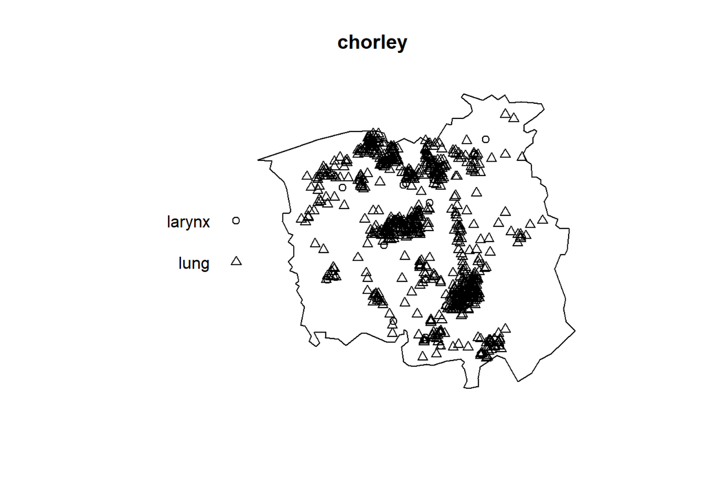

```r
# Load the `chorley` dataset included in the package
data(chorley)

# Plot the dataset to visualize the point locations
plot(chorley)
```

These data are larynx and lung cancer cases plotted at the locations of their homes.

Next, let’s compute the **K-function** using the **Kest()** function, a common tool for testing for **clustering** in **spatial point data**. The K-function measures the *expected number of points within a certain distance of each point*, and compares this to the *expected number of points if the points were randomly distributed*.

We then plot the K-function and test for significant clustering using the **envelope()** function, which creates an envelope around the K-function based on simulations under the null hypothesis of complete spatial randomness. The significance envelope can be used to test whether the observed K-function values are significantly different from the expected values under this randomness.

Note that in this example we will only use **nsim=5** for 5 simulations but this should be *99* or more, but that takes a lot more time.

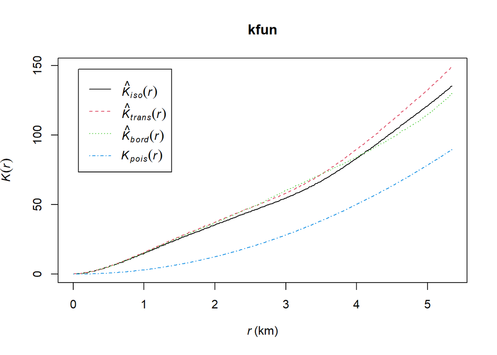

```r
# Compute the K-function to test for clustering
kfun <- Kest(chorley)

# Plot the K-function
plot(kfun)
```

```r
# Test for significant clustering using the envelope method
env.kfun <- envelope(chorley, Kest, nsim = 5, rank = FALSE)
```

```
## Generating 5 simulations of CSR  ...
## 1, 2, 3, 4,  5.
##
## Done.
```

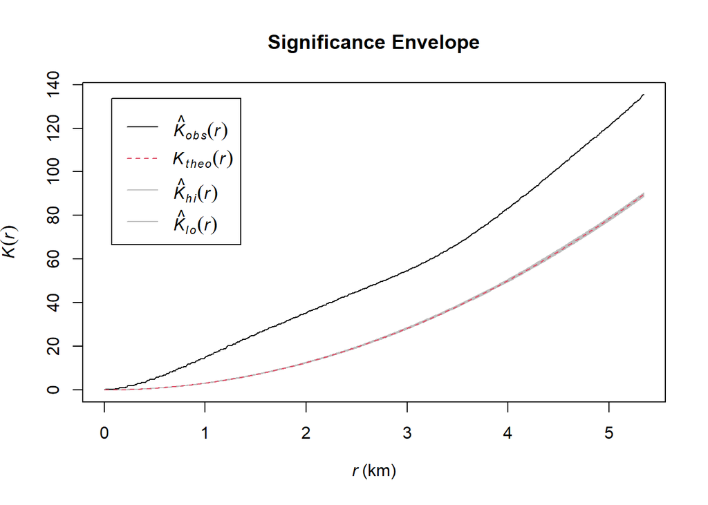

```r
# Plot the significance envelope
plot(env.kfun, main = "Significance Envelope")
```

The K-function tests for clustering at a certain distance, but we can repeat this process using the **L-function**. The L-function is similar to the K-function but measures the *expected distance to the nearest neighbor for each point*. The L-function can be used to test for clustering at *different distances*. We use the **Lest()** function for this.

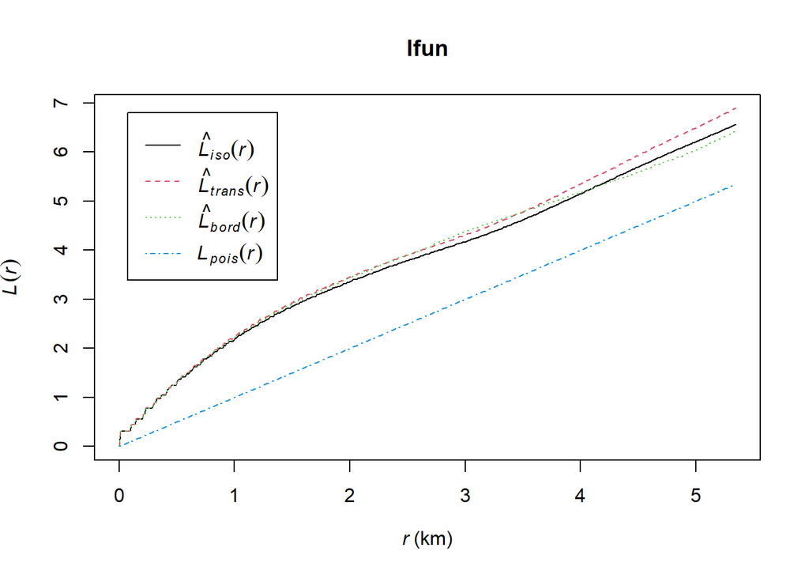

```r
# Calculate the L-function to test for clustering at different distances
lfun <- Lest(chorley)

# Plot the L-function
plot(lfun)
```

```r
# Test for significant clustering using the envelope method
env.lfun <- envelope(chorley,Lest, nsim = 5, rank = FALSE)
```

```
## Generating 5 simulations of CSR  ...
## 1, 2, 3, 4,  5.
##
## Done.
```

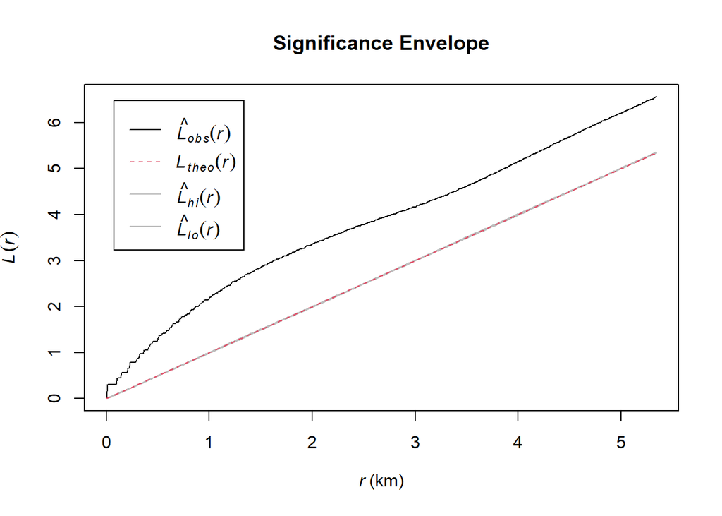

```r
### SHOULD BE 99 BUT TIME!!!

# Plot the significance envelope
plot(env.lfun, main = "Significance Envelope")
```

By analyzing the data using the K- and L-functions we are testing whether the points are significantly clustered or randomly distributed at different distances. This information can be used to guide further spatial analysis or to make inferences about the underlying processes that generated the data.

Last for this section, we can plot the point data with different *standard deviations* of an *isotropic smoothing kernel* by altering a parameter *sigma* to show the smoothed spatial intensity from a point pattern. Here’s what this looks like for these data:

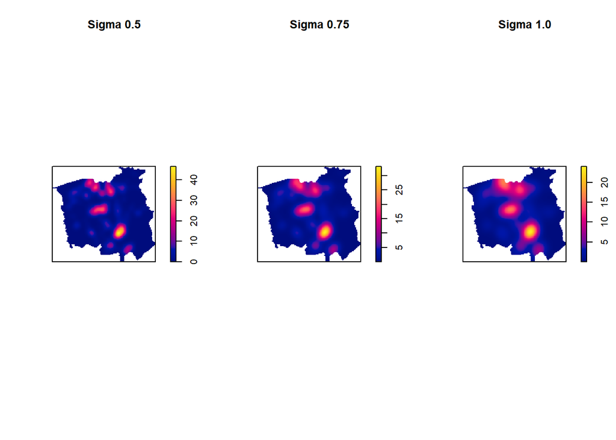

```r
par(mfrow = c(1, 3))  # set up to plot 3 plots on one row
# plot density at various levels of sigma
plot(density(chorley, sigma = 0.5), main = "Sigma 0.5")
plot(density(chorley, sigma = 0.75), main = "Sigma 0.75")
plot(density(chorley, sigma = 1), main = "Sigma 1.0")
```